# Fluid-electrolyte-pH balance

Jeffrey A. Walker

07 March, 2022

The paradox of fluid and electrolyte balance. Electrolyte levels are regulated by a hormone that controls fluid levels and fluid levels are regulated by a hormone that controls electrolyte levels. Huh.

# Summary

## The osmometer response to fluid balance

1. The osmometer of the hypothalamus is extremely sensitive to plasma osmolality.
2. Add Na+ to ECF by eating more Na+ then excreting so slight increase in plasma osmolality. The hypothalamus signals ADH secretion which ultimately leads to normal osmolality but increased ECF volume (above normal). ECF volume regulation by RAAS, which balances H2O and Na+ together, will kick in to balance this. This total response can take 1-2 days to balance.
3. Exercise and sweat loss. Sweat is hyposmotic so sweating increases plasma osmolality. The hypothalamus signals ADH secretion which leads to normal osmolality but decreased ECF volume (because some salt lost in sweat). ECF volume regulation by RAAS, which balances H2O and Na+ together, will kick in to balance this. This total response can take 1-2 days to balance.

## the baroreceptor response to fluid balance

1. ADH secretion is much less sensitive to fluid volume itself and it takes a fairly big (5-10%) loss of ECF volume to stimulate the baroreceptor response to ADH secretion.

# Osmoregulation – ECF Na+ (osmolality) is balanced by ADH, which regulates body fluid levels

Osmoregulation is mostly about Na+ balance, since Na+ is the dominant solute in the ECF. Here, by ECF, I mean the combination of the plasma and IF (so not including the fluid in the nephron/CD which is technically part of the ECF). Na+ concentration in the plasma and IF is the same. ICF Na+ is very low because of Na+/K+ pump activity in all cells. Imbalance of Na+ causes small changes in fluid volume between ICF and ECF compartments. If [Na+] increases a little, water shifts from ICF to ECF. If [Na+] decreases a little, water shifts from ECF to ICF.

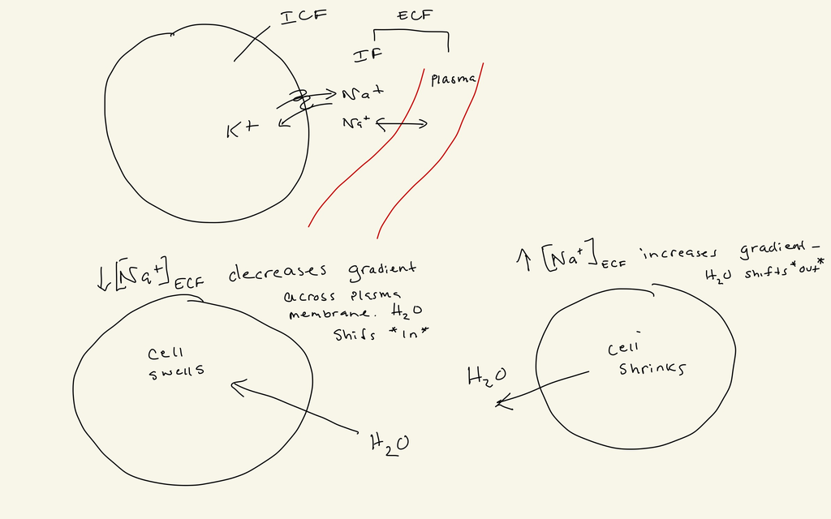

1. Increased ECF osmolality
- increased Na+ gain relative to water gain increases ECF osmolality. For example, if we eat dry, salty foods without drinking
- increased water loss relative to Na+ loss increases ECF osmolatlity. For example, if we go for a run and sweat (we lose more water than Na+ in sweat)

homestatic consequence – signal systems to increase body water. The increased water dilutes the ECF back to normal

What are the consequences that we experience? We urinate less, we become thirsty.

Pathological consequences - pathologically high ECF Na+ concentration is **hypernatriemia**. There is a big fluid shift from cells to ECF

2. Decreased ECF osmolality
- increased Na+ loss relative to water loss decreases ECF osmolality. I’m not sure of a behavior that causes this, but there are pathologies that could cause this.
- increased water gain relative to Na+ gain decreases ECF osmolatlity. For example, if we drink water without eating.

homestatic consequence – signal systems to decrease body water. The decreased water concentrates the ECF back to normal

What are the consequences that we experience? We urinate more, we lose our thirst.

Pathological consequences - pathologically low ECF Na+ concentration is **hyponatremia**. There is a big fluid shift from ECF to cells. This is catastrophic. Across the globe every year, there are a few deaths in marathon runners due to hyponatremia. The runners drink too much water without also replacing electrolytes.

### ADH

This peptide hormone has several names. Physiologists tend to use **antidiuretic hormone (ADH)** and the medical community tends to use **argenine vasopressin** (or simply **vasopressin**). I use ADH. The two names give away its principle actions. ADH is an **anti-diuretic**. A diuretic makes you pee. Anti anti-diruretic keeps you from peeing. Vasopressin means to “squeeze the vessels” and ADH is a vasoconstrictor.

ADH is secreted by the posterior pituitary, so is a **neurohormone** (a hormone secreted by a neuron). The cell body of the neurons are in the hypothalamus. Osmoreceptors in the hypothalamus regulate ADH secretion. The osmoreceptors are very sensitive to ECF osmolality.

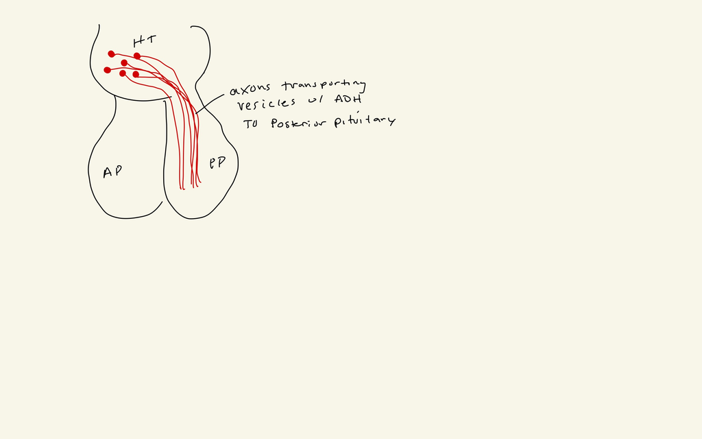

#### ADH stimulation

1. Increased ECF osmolality: H2O moves from ICF to ECF and osmoreceptor cell shrinks. This stimulates depolarization and action potential. Depolarization of axon terminal causes ADH secretion.
2. Decreased ECF osmolality: H2O moves from ECF to ICF and osmoreceptor cell swells. This inhibits depolarization and action potential. There is no ADH secretion.

#### ADH action on the kidney

ADH binds to receptors on the epithelial cells of the collecting duct and signals these cells to translocate aquaporin to the apical membrane. The basolateral membrane always has a high density of aquaporins. With aquaporins expressed on both sides of the cell, the cell becomes permeable to water, and water moves from the urine to the IF of the renal pyramid (and into the blood) up the solute concentration gradient created by the loop of Henle. The consequence is more water moving from the nephron/CD compartment to the plasma/IF and decreased IF/plasma (or ECF) osmolality. You experience this as peeing less frequently.

To understand whats going on when ADH levels are low, you have to remember that cells are constantly endocytosing bits of plasma membrane including whatever proteins occur on that bit so unless the cell is simultaneously moving the same proteins to the cell via the ER/golgi/vesicle system, there will be net loss of the protein from the plasma membrane. So, if ADH levels drop, there is no singal to move aquaporin to the apical membrane and aquaporin density on the apical membrane will decrease, making the membrane less permeable to water. The consequence of this is more water moving from the IF/plasma to the nephron/CD (and to the bladder) which increases the IF/plasma osmolality. You experience this as peeing more frequently.

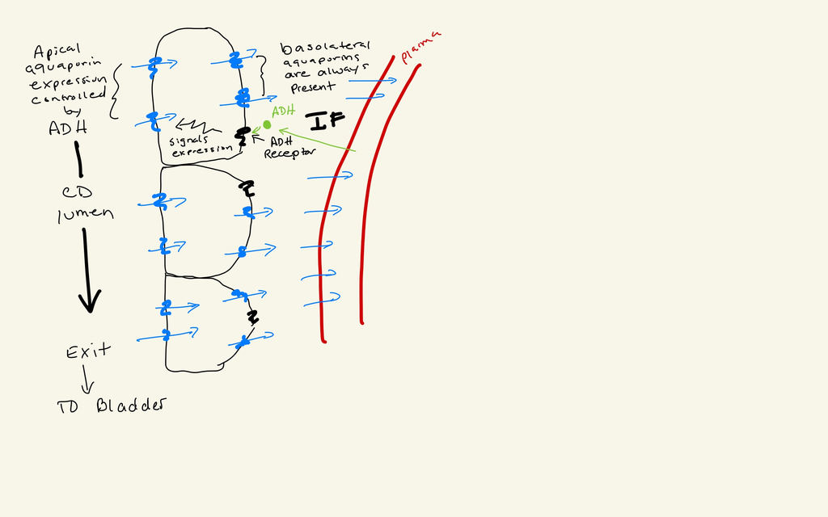

# Body fluid levels is balanced by the Renin-Angiotensin-Aldosterone system (RAAS), which regulates Na+/K+ levels

The Renin-Angiotensin-Aldosterone system is super important. Briefly. Renin is an enzyme secreted into the blood by the kidney. The enzyme cleaves the peptide prohormone angiotensinogen to angiotensin I. Angiotensin I doesn’t do much. The enzyme **angiotensin converting enzyme (ACE)** cleaves angiotensin I to angiotensin II. Angiotensin II is a systemic vasoconstrictor and stimulates ADH secretion by the posterior pituitary and aldosterone secretion by the adrenal cortex. ADH function is described above. Aldosterone targets DCT cells and increases Na+ reabsorption and increases K+ secretion. **angiotensin converting enzyme 2 (ACE2)** cleaves angiotensin II to biologically inactive fragments. By removing angiotensin II from the blood, ACE2 has opposite consequence of ACE.

Background terminology: when an enzyme **cleaves** a polypeptide, it breaks a peptide bond causing the polypeptide to split into two fragments. This is a fundamental process in the synthesis of many many proteins.

1. Decreased ECF
- decreased ECF including decreased plasma volume. This decreases blood pressure and can reduce blood flow to brain or cause too little GFR (without local mechanism to counteract). Decreased ECF was probably pretty common in lots of human communities due to lack of access to clean, potable water (ocean water is not very drinkable. A lot of freshwater is contaminated by bacteria that make us sick).
2. Increased ECF
- increased ECF including increased plasma volume. This increases blood pressure. Some consequences of this are increased strain on and damage to blood vessels, increased afterload on ventricle to generate force to open aortic valve (this causes heart to enlarge to generate large contractile force), and potentially increased GFR (without local mechanisms to counteract this)

### RAAS stimulation

#### decreased ECF

1. baroreceptor cells in afferent arteriole sense less stretch and signal JG cells to secrete renin
2. Macula Densa cells in DCT sense less Na+ (see tubuloglomerular feedback section of kidney explainer) and signal JG cells to secrete renin.
3. baroreceptors in carotid sense less stretch and activate sympathetic division. Sympathetic synapse with JG cells and signal JG cells to secrete renin.

The consequence of increased plasma renin is increased angiotensin II. The consequence of this is

1. increased vasoconstriction -> increased blood pressure
2. increased thirst -> increased water intake
3. increased plasma ADH -> increased water reabsorption
4. increased aldosterone -> increased Na+ reabsorption

#### increased ECF

1. opposite of 1-3 above, also
2. baroreceptor in atria signals secretion of **Atrial Natriuretic Peptide (ANP)**. ANP causes natriuresis (to pee natrium or Na+) because it inhibits aldosterone. ANP also inhibits sympathetic and angiotensin.

The consequence of increased plasma ANP is 1. increased vasodilation -> decreased blood pressure 3. decreased plasma ADH -> decreased water reabsorption -> decreased blood pressure 4. decreased aldosterone -> increased Na+ secretion

### Aldosterone

Aldosterone is a mineralocortacoid (steroid) hormone secreted by the adrenal cortex. Remember that other corticosteroids (like cortisol) are regulated mostly by ACTH but aldosterone is mostly regulated by angiotensin II. Aldosterone targets DCT cells and signals these cells to upregulate expression of Na+/K+ pumps on the basolateral border of the tubal epithelial cells. This increases Na+ transport across the whole cell from the lumen to the IF, and so increases Na+ reabsorption. It also increases K+ secretion. Reabsorbing both water and Na+ maintains electrolyte balance.

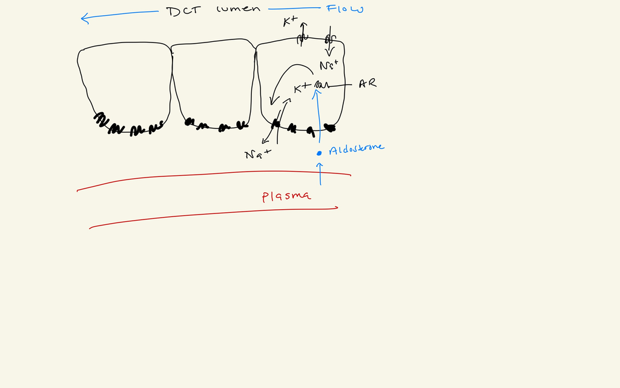

# pH balance

Remember what pH is. The pH of a solution is the negative exponent of the concentration of protons in solution [H+]. Know negative exponents! Pure H$_2$O spontaneously dissociates into H+ and OH-. Remember that H+ is a proton. Not kinda like a proton but *is* a proton. The protons in water are attracted to the water molecules so these are often written as H3O+. An acid (such as a ketone body) gives up H+ to the solution increasing the [H+]. A base (or a **buffer**) scrubs H+ from the solution decreasing the [H+]. A solution with lower [H+] is more **alkaline**. A solution with higher [H+] is more **acidic.** Since the pH is the negative exponent of the concentration, then more acidic (more H+) means a smaller number. Compare: